# mjsalnic_FinalHomeworkCode_02

majo

16/9/2019

# Introduction to the Assignment

This is code for [Homework 02] associated with modules 6 and 7

(https://fuzzyatelin.github.io/bioanth-stats/homework-02.html)

> Every Saturday morning, at the same time, a primatologist goes and sits in the forest to listen for titi monkey calls, counting the number of calls they hear in a 2 hour window from 5am to 7am. Based on previous knowledge, she believes that the mean number of calls she will hear in that time is exactly 15. Let X represent the appropriate Poisson random variable of the number of calls heard in each monitoring session.

## Question 1

Question 1: What is the probability that she will hear more than 8 calls during any given session?

The expected average of calls for that period of time is 15, then the probability of hearing more than 8 is 96%

```r
ppois(8, lambda=15, lower=FALSE)   # upper tail
```

```
## [1] 0.9625535
```

## Question 2

What is the probability that she will hear no calls in a session?

The expected average of calls for that period of time is 15, then the probability of no hear any call is extremely low

```r
dpois(x=0, lambda = 15)
```

```
## [1] 3.059023e-07
```

## Question 3

What is the probability that she will hear exactly 3 calls in a session?

The expected average of calls for that period of time is 15, then the probability of hearing exactly 3 calls is 0.01720701%

```r
dpois(x=3, lambda = 15)
```

```
## [1] 0.0001720701
```

## Question 4

Plot the relevant Poisson mass function over the values in range 0 ≤ x ≤ 30

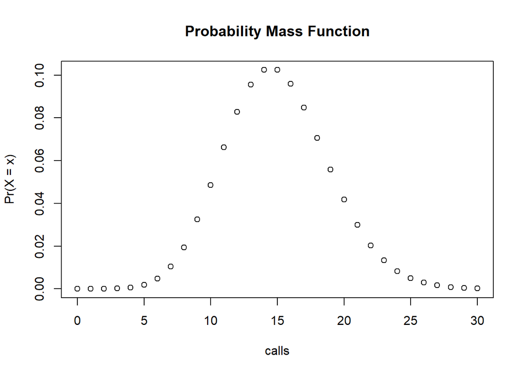

```r
rv<-0:30
fs<-dpois(rv, lambda = 15)
plot(rv,fs, xlab = "calls", ylab = "Pr(X = x)", main = "Probability Mass Function")
```

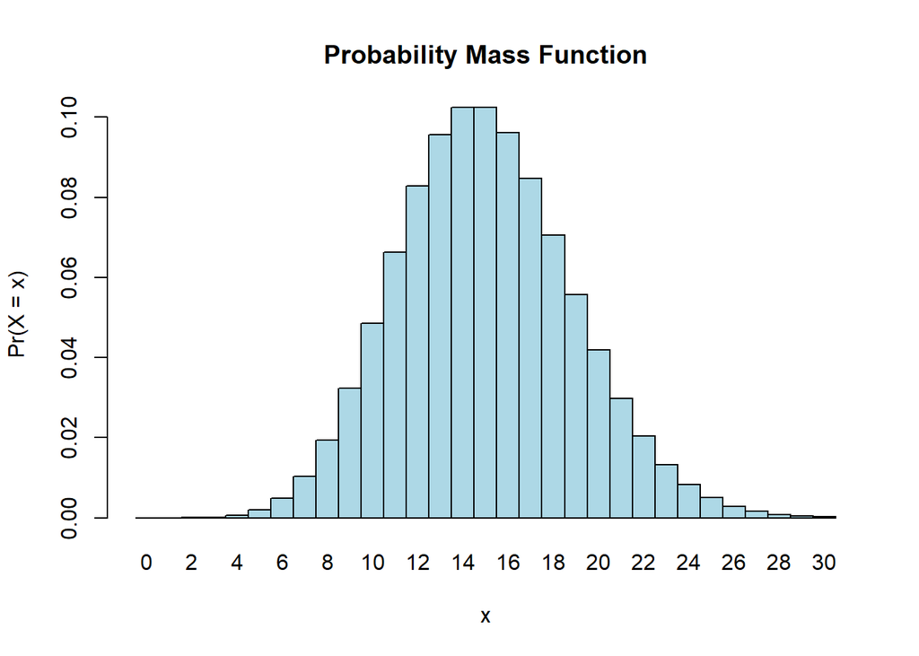

```r
x<-0:30
l=15
probset<-dpois(x=x,lambda=l)
barplot(probset,names.arg=x,space=0,xlab="x",ylab="Pr(X = x)",main="Probability Mass Function", col = "light blue")
```

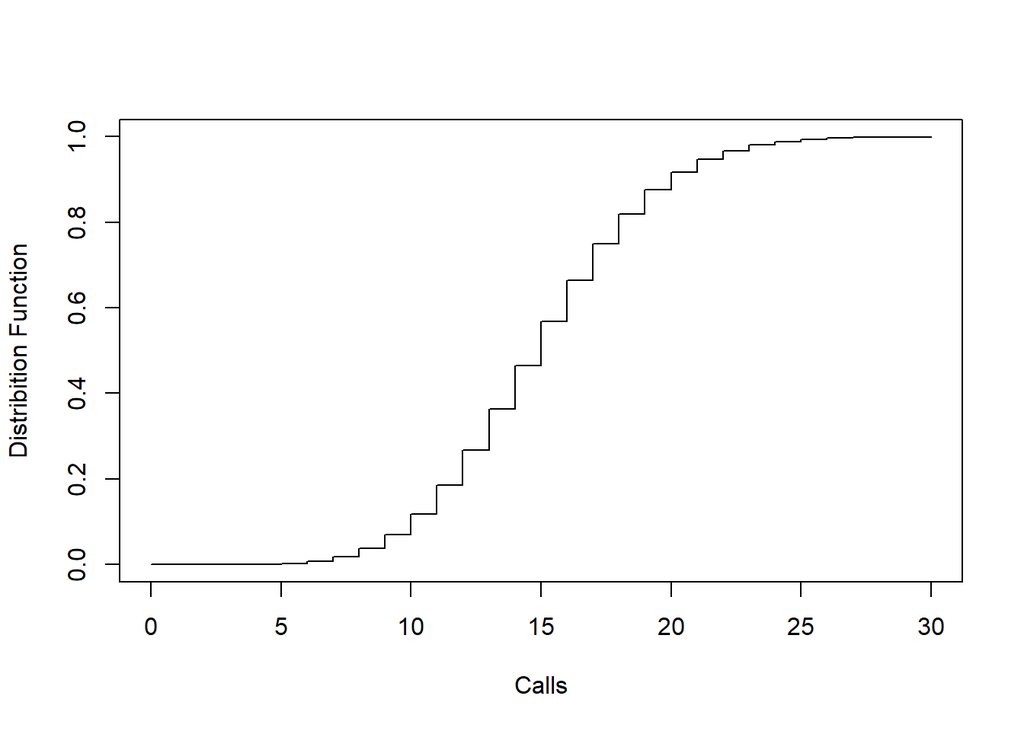

```r
rv<-0:30
fs<-ppois(rv,lambda=15)
plot(rv,fs,type = "s", xlab = "Calls", ylab = "Distribition Function")
```

Simulate 104 results from this distribution (i.e., 2 years of Saturday monitoring sessions)

```r
sim<-rpois(104, lambda = 15)
sim
```

```
##   [1] 12 19 20 11 15 18 13 14 17 10 13 23 10 11 13 32 14 12 13 12 10 15 14
##  [24] 12 13 18 10  9 17 15 14 13 15 17 12  8 24 11 12 16 16 20 15 20 16 17
##  [47]  6 14 20 15 13 10 19 18 19  9 20 11 18 13 10 20 13 20 17 17 14 17 13
##  [70] 15  7 20 22 11 14 13 13 20 16 13 17 14  8 15 26 11 20 20 16 13 18 15
##  [93] 13 13 10  9 19 12 24 14 11 11 12 18
```

```r
summary(sim)
```

```
##    Min. 1st Qu.  Median    Mean 3rd Qu.    Max.
##     6.0    12.0    14.0    14.9    18.0    32.0
```

```r
#another way to do it
rpois(104,15)
```

```
##   [1] 13 12 17 20 15 22 19 13 14 12 14 11 13 22 11 14 16 16 13 15 15 12 16
##  [24] 14 13 13 22 12 22 11 17 13 16 19 15 15 22 19 12 14 17 15 12 19 15 18
##  [47] 16 10 16 14  8 14 19 12 13 22 20 19 16 19 18 14 12 19 16 12 10 10 18
##  [70] 13 15 10 16 16 24 19 13 18 18 15 11 21 15 14 11 18 16 15 19 12 13 11
##  [93] 14 17 15 18 18 16 19 12 14 19 18 14
```

## Question 6

Plot the simulated results using hist() and use xlim() to set the horizontal limits to be from 0 to 30. How does your histogram compare to the shape of the probability mass function you plotted above? The shape looks different, it seems in the histogram the higher frequency of the calls falls below 15 (the expected mean), the distribution of the frequencies of the calls is different.

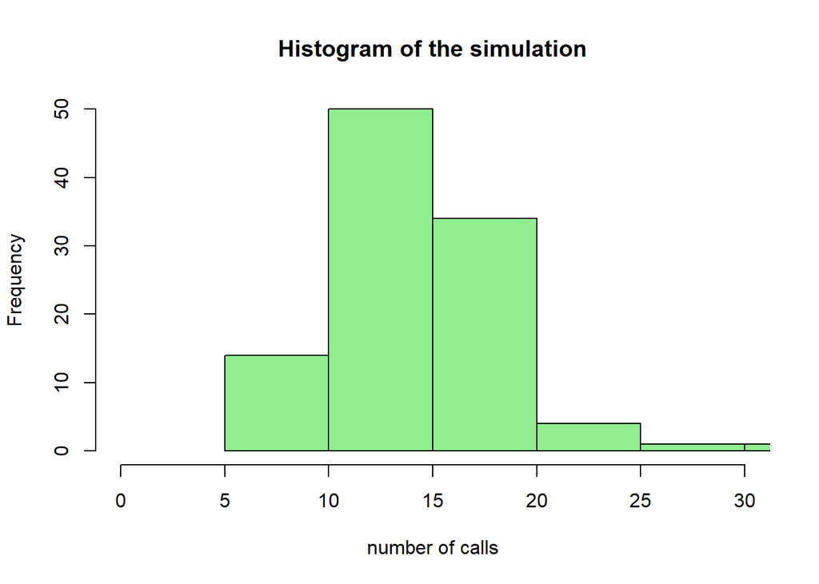

```r
hist(sim, xlim = c(0,30), main = "Histogram of the simulation", col = "light green", xlab = "number of calls")
```

## Challenges

- 1. problem 1: I read r coding blogs to do this assignment and also followed the module 08 practice code, I found two different ways to answer question 5 but not sure if any of those is ok
  2. problem 2: I don’t understand what the distribution function does.
  3. problem 3: I think the most difficult to me is not to have an idea if my code is accurate to answer the questions, so it’s like being blind-coding